# CannaQuant - Descriptives

8 October 2024

# Data cleaned

in “clean data.R”

# Sample characteristics

First let’s look at country-specific distributions

## RESPONSES

How many valid responses are there in each country?

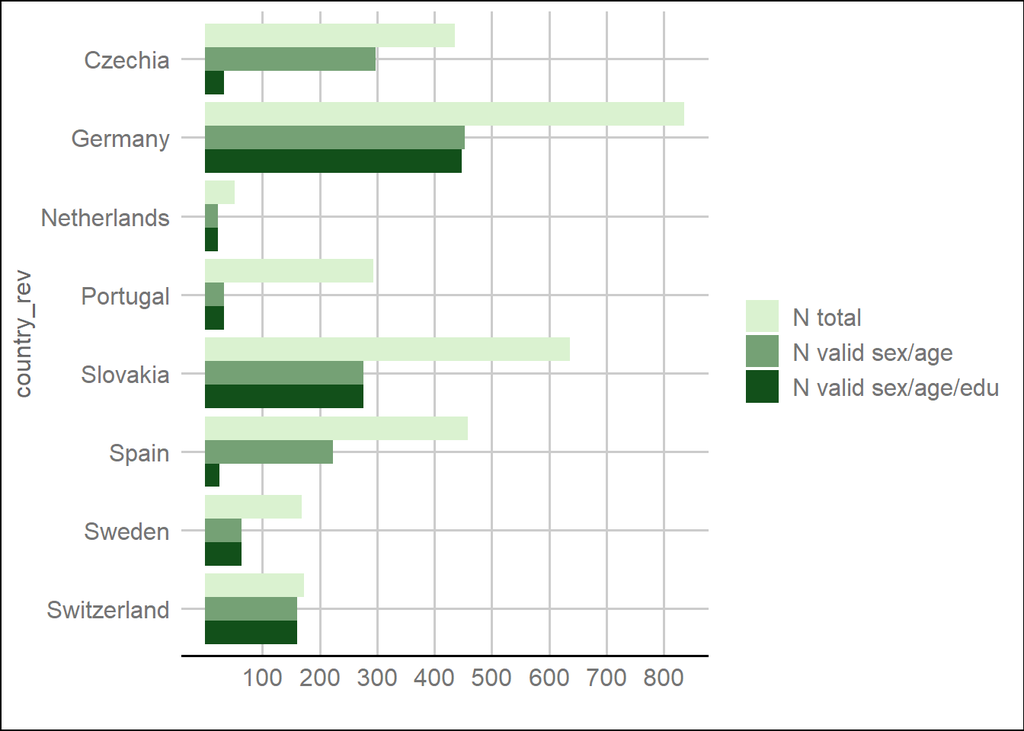

### Lessons learned

1. In all countries (except CH): removing missing values in sex/age reduces the sample size substantially (more in PT than in other countries)
2. In CZ and ES: there was a survey programming problem resulting in many people not reporting their education

**for main analyses: either stick to the plan of complete education analyses or depart from study protocol and remove education as variable??**

## SOCIODEMOGRAPHICS

How are sex and age distributed?

```
##        country share_men age_mean age_median  age_IQR
##         <fctr>     <num>    <num>      <num>   <char>
## 1:     Czechia 0.7818792 22.86577         21    18-24
## 2:     Germany 0.9006623 37.43488         37    30-43
## 3: Netherlands 0.7727273 31.45455         26 24.25-30
## 4:    Portugal 0.5151515 25.30303         23    20-26
## 5:    Slovakia 0.7210145 29.90942         29    24-35
## 6:       Spain 0.6278027 30.59193         28    23-38
## 7:      Sweden 0.7500000 32.01562         29 22.75-39
## 8: Switzerland 0.7142857 30.14286         25    21-37
```

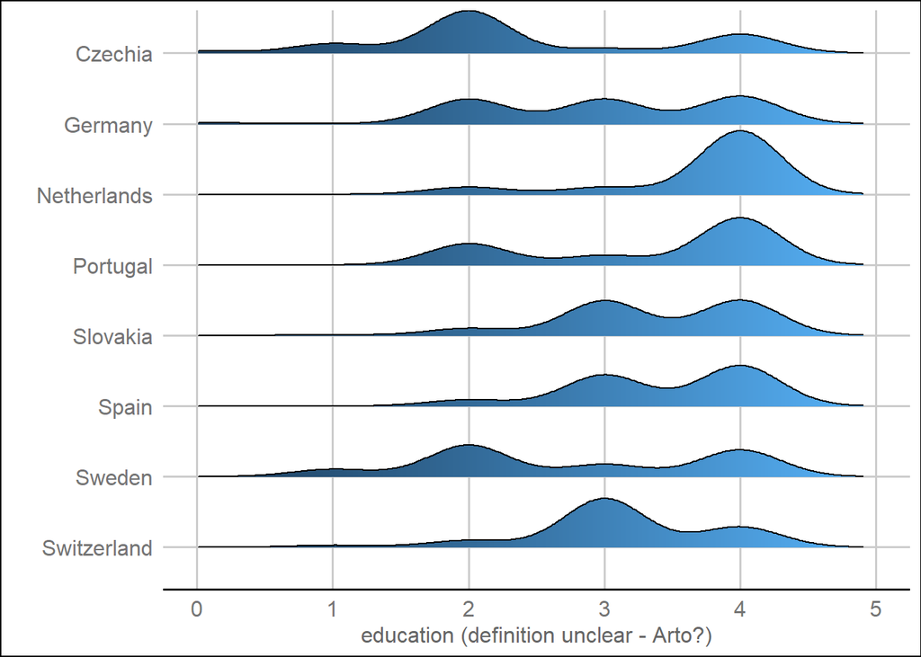

### Lessons learned

AGE: Respondents are youngest in Czechia/Portugal and oldest in Germany/Sweden

EDUCATION: Pronounced variations in education across countries

## CANNABIS USE FREQUENCY

How is cannabis use frequency distributed in the different countries?

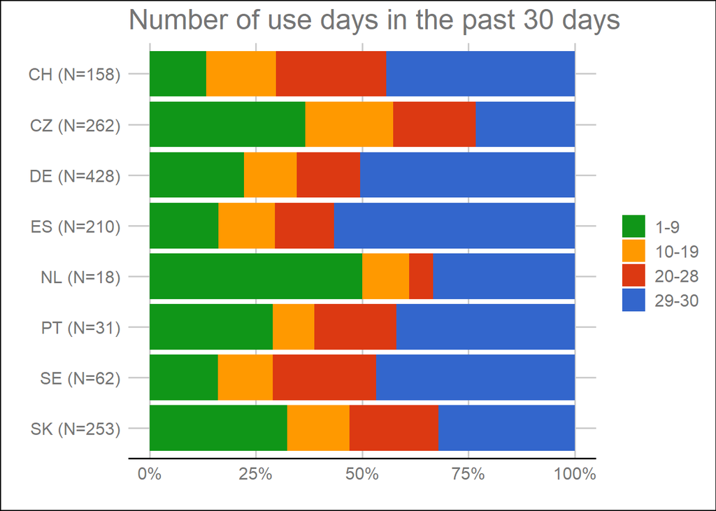

```
##       iso prev_daily
##    <fctr>      <num>
## 1:     CZ  0.2328244
## 2:     SK  0.3201581
## 3:     NL  0.3333333
## 4:     PT  0.4193548
## 5:     CH  0.4430380
## 6:     SE  0.4677419
## 7:     DE  0.5046729
## 8:     ES  0.5666667
```

### Lessons learned

Prevalence of (near) daily cannabis use varies across countries, with highest share in Sweden, Germany and Spain

## CAST SCORE

How is the CAST score distributed in the different countries? Cutoff >= 7 indicates risk for severe use disorder

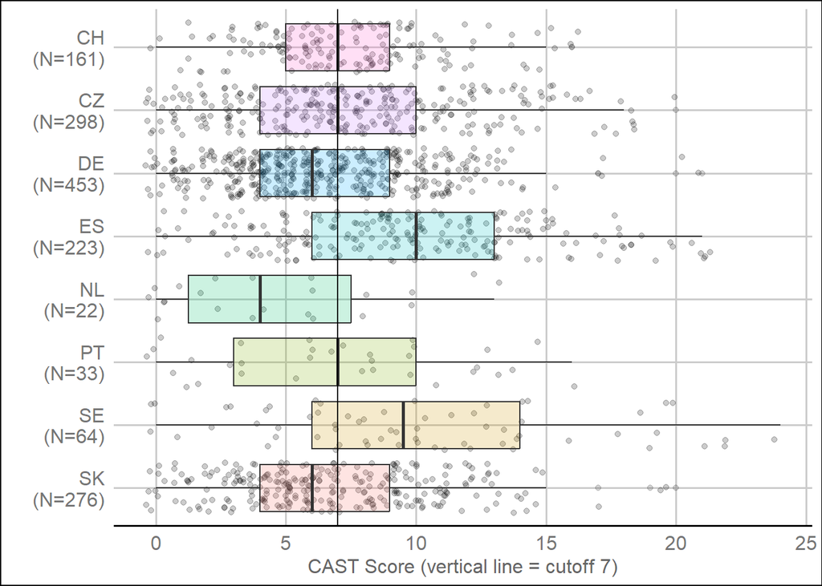

```
## highrisk
##       low      high
## 0.4568627 0.5431373
```

```
##        country CAST_7_or_more valid_N
##         <fctr>          <num>   <int>
## 1:     Czechia      0.5704698     298
## 2:     Germany      0.4503311     453
## 3: Netherlands      0.2727273      22
## 4:    Portugal      0.5454545      33
## 5:    Slovakia      0.4818841     276
## 6:       Spain      0.7354260     223
## 7:      Sweden      0.7187500      64
## 8: Switzerland      0.5590062     161
```

### Lessons learned

1. About 54% are at risk for CUD (CAST>=7)
2. Highest percentages is highest in Sweden (72%) Spain (73%)

## THC CONTENT

How is the average THC content distributed in the different countries?

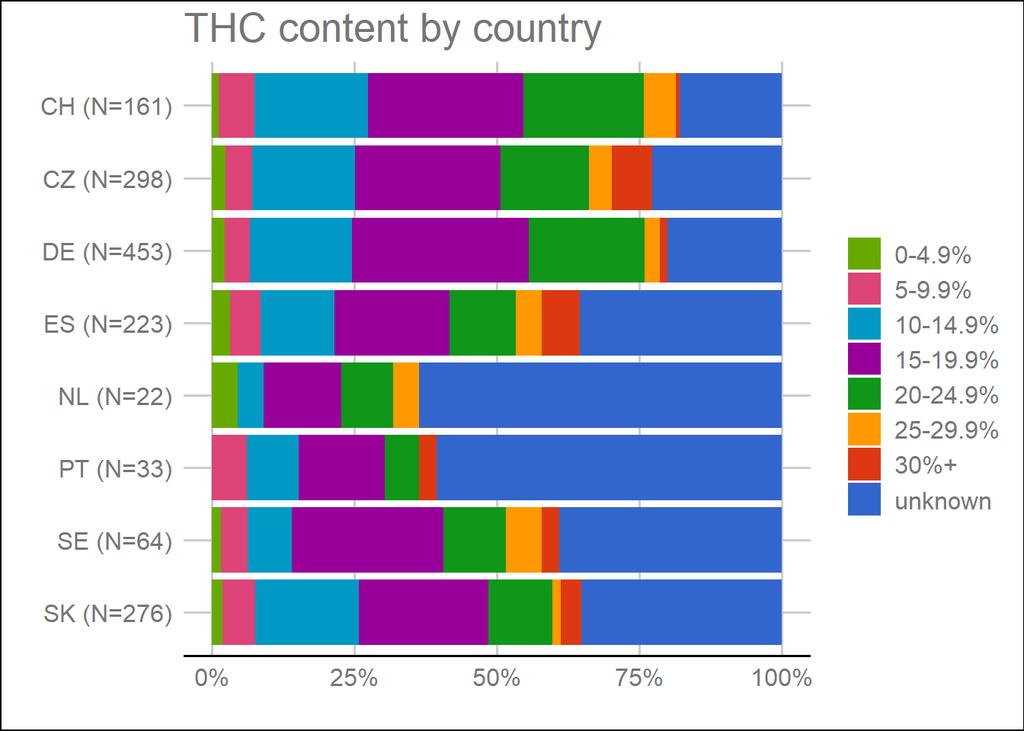

### Lessons learned

1. Products <20% THC make up largest share
2. Very low (>50%) THC knowledge in NL and PT - data problem?

# Cannabis amounts

## Product preference

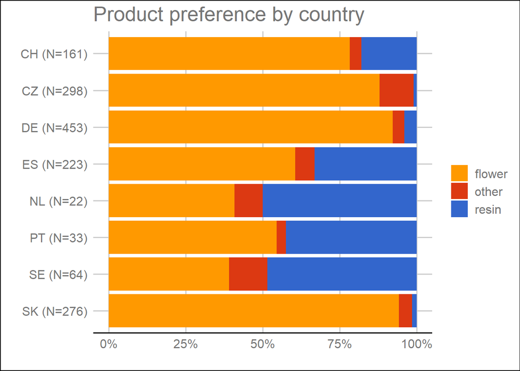

### Lessons learned

1. High preference of cannabis flower in all countries
2. Resin plays a major role in ES, NL, PT and SE

## Crude Weight Assessment (CWA)

1. Removed top 5% -> very large amounts (CZ: >111g; DE: >70g; NL: 39g; PT: 153g; SK: >60g; ES: >150g; SE: >150g; CH: >104g) for illustration
2. Analysed only flowers due to small N of resin

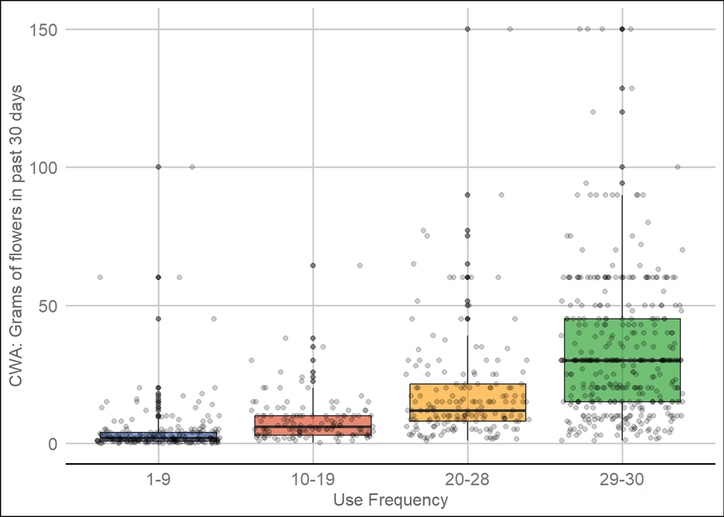

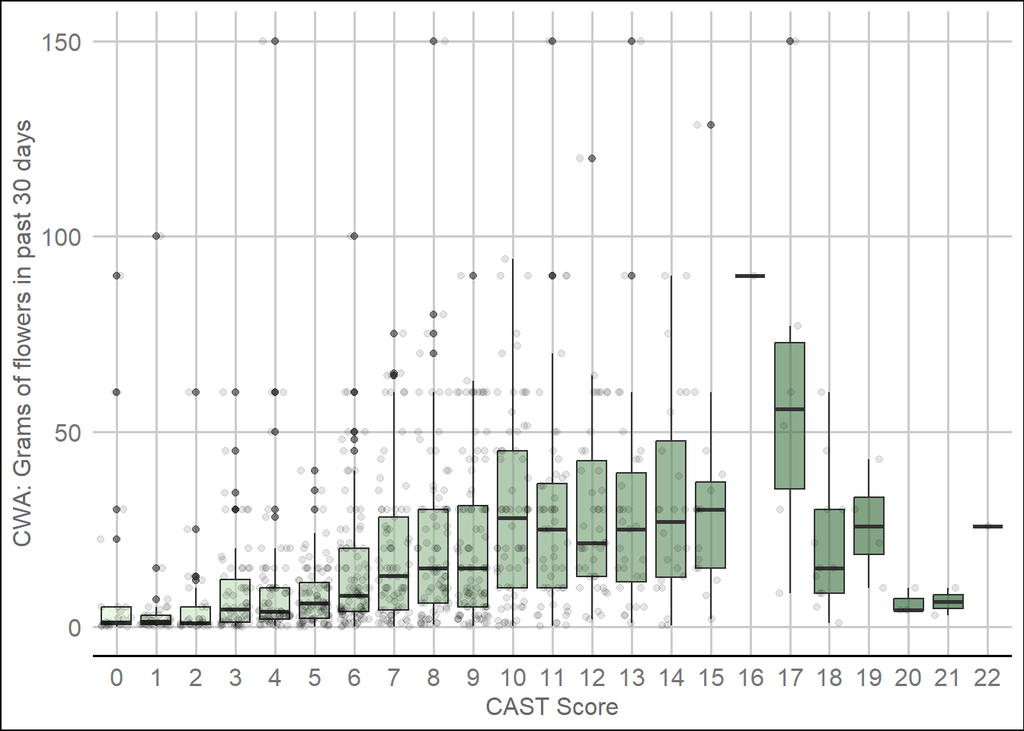

### Lessons learned

1. Increased quantities (Crude Weight Assessment) among people with higher use frequency and higher CUD risk

## CannaQuant Assessment (CQ)

1. Removed top 5% -> very large amounts (CZ: >75; DE: >75g; NL: >35g; PT: >170g; SK: >88g; ES: >117g; SE: >166g; CH: >193g) for illustration
2. Analysed only flowers due to small N of resin

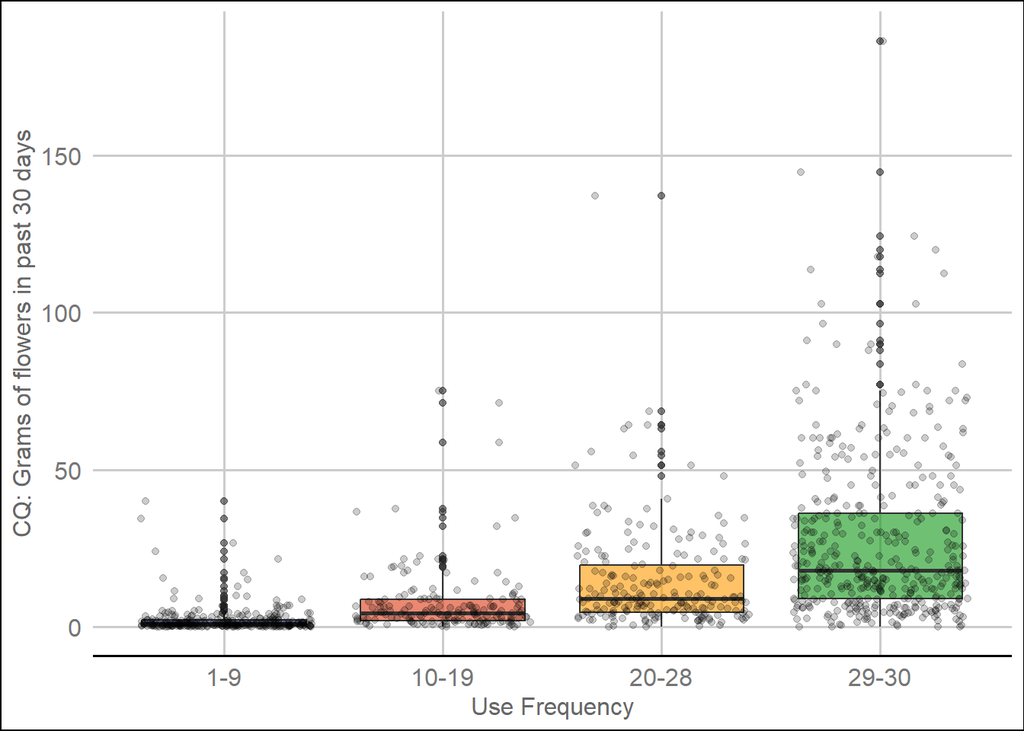

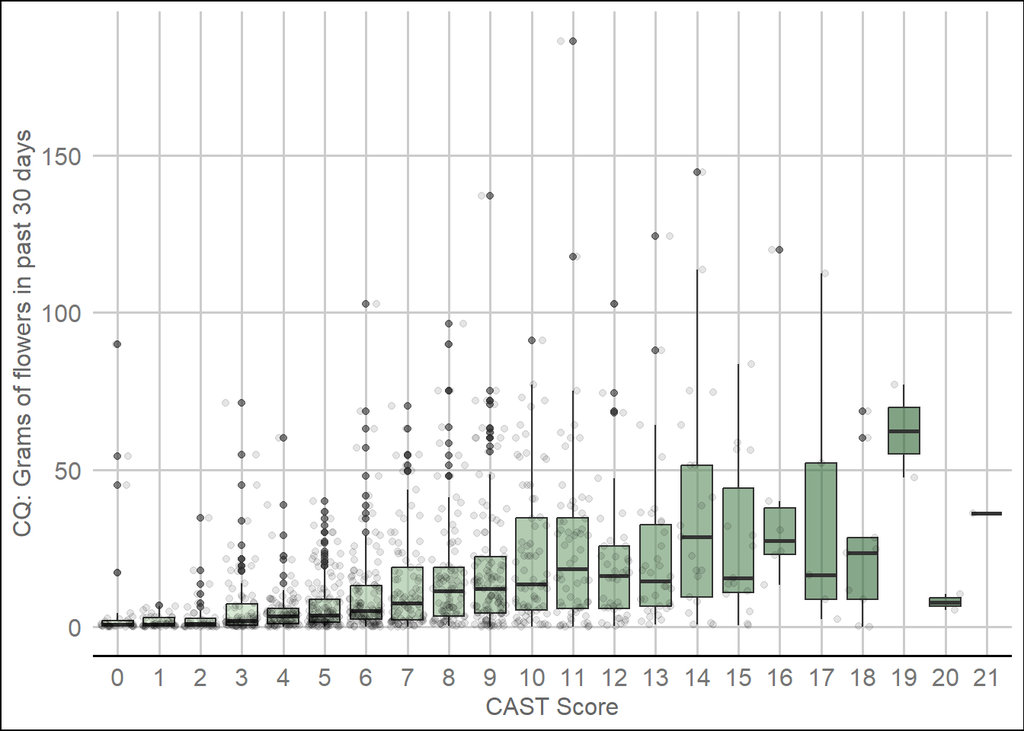

### Lessons learned

1. Increased quantities (CannaQuant) among people with higher use frequency and higher CUD risk